# Визуализация биомедицинских данных. Д/з №1

Anastasia Soroka

2023-11-05

# 1. Импорт данных и первичный анализ

Данные по базовым показателям здоровья индивида и сумме, которую страховая компания заплатила за его лечение в год. Обычно эти данные используют, чтобы потренироваться в предсказании того, как определённые характеристики индивида повышают траты страховой компании (и, соответственно, должны быть заложены в цену страховки).

```r
data <- read_csv("insurance_cost.csv", show_col_types = FALSE)
head(data)
```

```
## # A tibble: 6 × 7
##     age sex      bmi children smoker region    charges
##   <dbl> <chr>  <dbl>    <dbl> <chr>  <chr>       <dbl>
## 1    19 female  27.9        0 yes    southwest  16885.
## 2    18 male    33.8        1 no     southeast   1726.
## 3    28 male    33          3 no     southeast   4449.
## 4    33 male    22.7        0 no     northwest  21984.
## 5    32 male    28.9        0 no     northwest   3867.
## 6    31 female  25.7        0 no     southeast   3757.
```

### Data summary

```r
# Data summary
data_info <- summary(data)
data_info
```

```
##       age            sex                 bmi           children
##  Min.   :18.00   Length:1338        Min.   :15.96   Min.   :0.000
##  1st Qu.:27.00   Class :character   1st Qu.:26.30   1st Qu.:0.000
##  Median :39.00   Mode  :character   Median :30.40   Median :1.000
##  Mean   :39.21                      Mean   :30.66   Mean   :1.095
##  3rd Qu.:51.00                      3rd Qu.:34.69   3rd Qu.:2.000
##  Max.   :64.00                      Max.   :53.13   Max.   :5.000
##     smoker             region             charges
##  Length:1338        Length:1338        Min.   : 1122
##  Class :character   Class :character   1st Qu.: 4740
##  Mode  :character   Mode  :character   Median : 9382
##                                        Mean   :13270
##                                        3rd Qu.:16640
##                                        Max.   :63770
```

### Data describe

```r
data_info_2 <- describe(data, na.rm = TRUE, skew = FALSE, ranges = TRUE)
data_info_2
```

```
##          vars    n     mean       sd     min      max    range     se
## age         1 1338    39.21    14.05   18.00    64.00    46.00   0.38
## sex*        2 1338     1.51     0.50    1.00     2.00     1.00   0.01
## bmi         3 1338    30.66     6.10   15.96    53.13    37.17   0.17
## children    4 1338     1.09     1.21    0.00     5.00     5.00   0.03
## smoker*     5 1338     1.20     0.40    1.00     2.00     1.00   0.01
## region*     6 1338     2.52     1.10    1.00     4.00     3.00   0.03
## charges     7 1338 13270.42 12110.01 1121.87 63770.43 62648.55 331.07
```

```r
na_count_cols <- colSums(is.na(data))
na_count_cols #Сколько N/A в каждом столбце
```

```
##      age      sex      bmi children   smoker   region  charges
##        0        0        0        0        0        0        0
```

## 2. Гистограммы всех нумерических переменных

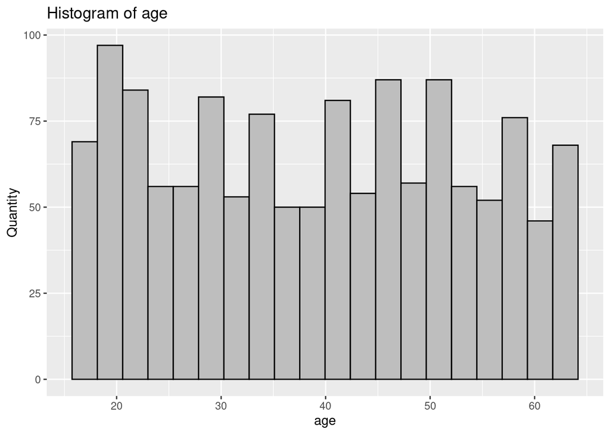

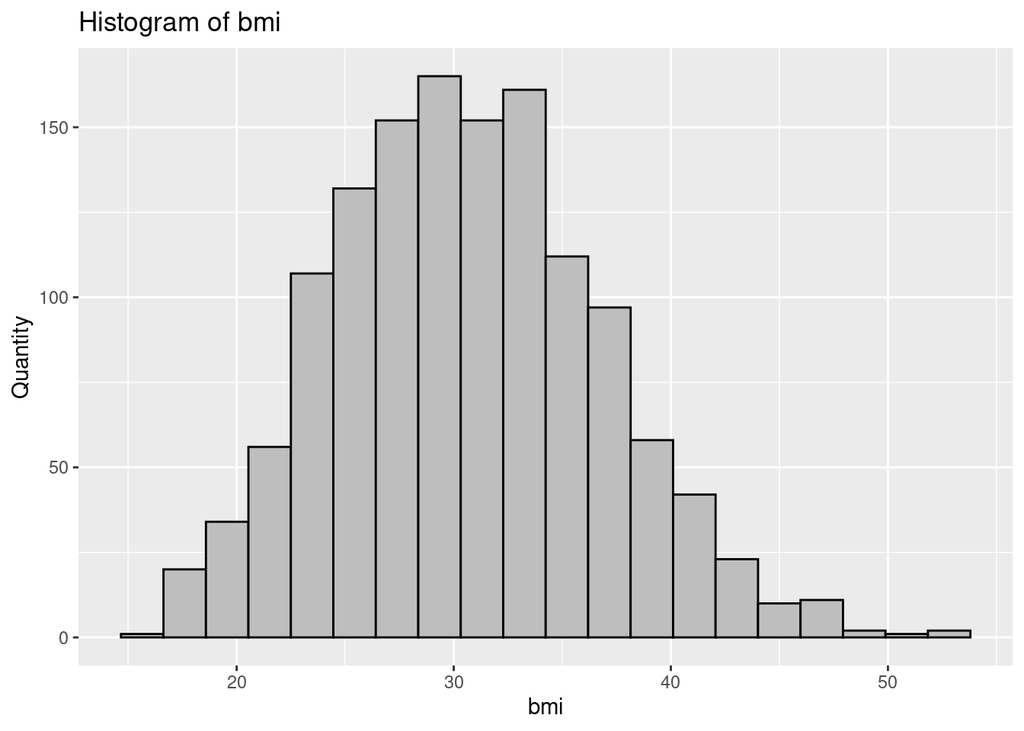

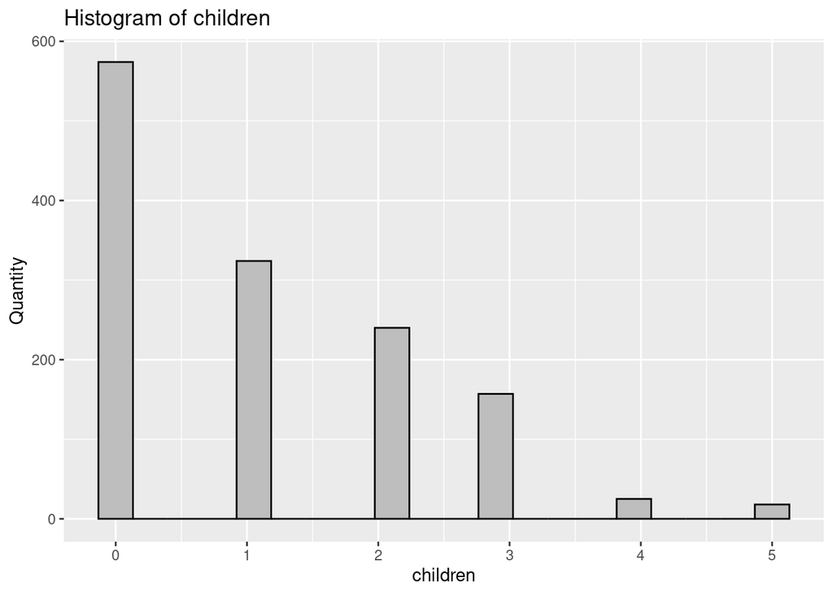

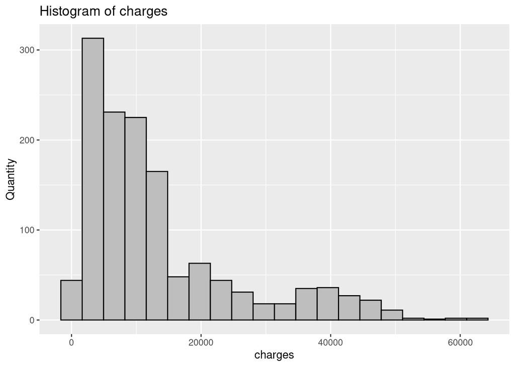

```r
data_numeric <- data %>%
  select_if(is.numeric)


for (var in names(data_numeric)) {
  print(
    ggplot(data, aes_string(x = var)) +
    geom_histogram(bins = 20, fill = "grey", color = "black") +
    ggtitle(paste("Histogram of", var)) +
    xlab(var) +
    ylab("Quantity")
  )
}
```

## 3. График плотности по колонке charges

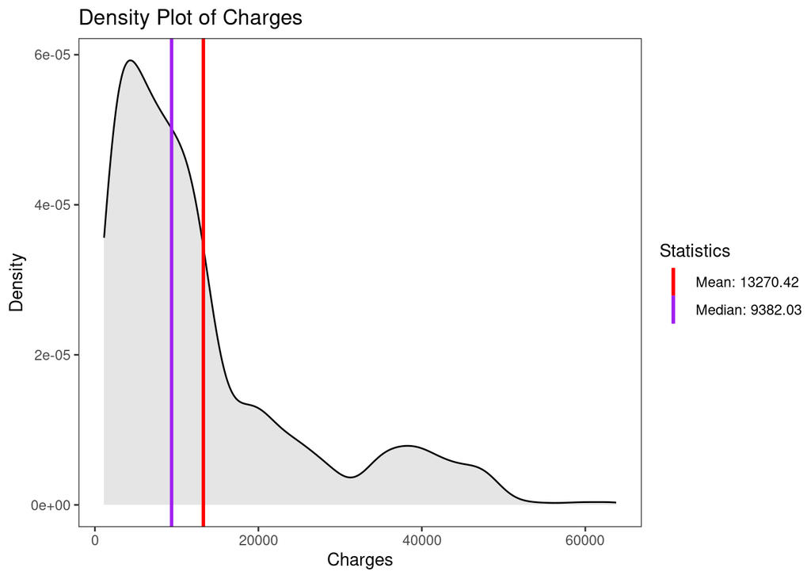

```r
mean_charges <- mean(data$charges)
median_charges <- median(data$charges)

gg_charges_density <- ggplot(data, aes(x = charges)) +
  geom_density(fill = "grey", alpha = 0.4) +
  geom_vline(aes(xintercept = mean_charges, color = "Mean"), size = 1) +
  geom_vline(aes(xintercept = median_charges, color = "Median"), size = 1) +
  scale_color_manual(name = "Statistics", values = c("Mean" = "red", "Median" = "purple"), labels = c("Mean" = paste("Mean:", round(mean_charges, 2)),
           "Median" = paste("Median:", round(median_charges, 2)))) +
  labs(x = "Charges", y = "Density", title = "Density Plot of Charges") +
  theme_test()



print(gg_charges_density)
```

## 4. Отношение переменных charges(1), sex (2) smoker (3)

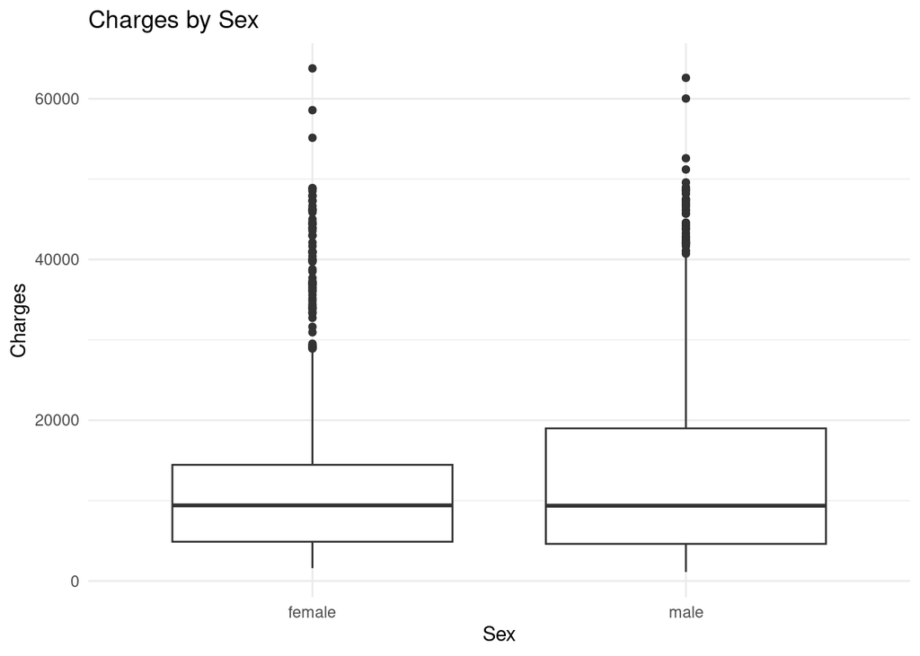

```r
p1 <- ggplot(data, aes(x=sex, y = charges)) +
  geom_boxplot() +
  labs(title = "Charges by Sex", x = "Sex", y="Charges") +
  theme_minimal()

p2 <- ggplot(data, aes(x = smoker, y = charges)) +
  geom_boxplot() +
  labs(title = "Charges by Smoker", x = "Smoker", y = "Charges") +
  theme_minimal()

p3 <- ggplot(data, aes(x = region, y = charges)) +
  geom_boxplot() +
  labs(title = "Charges by Region", x = "Region", y = "Charges") +
  theme_minimal()


print(p1)
```

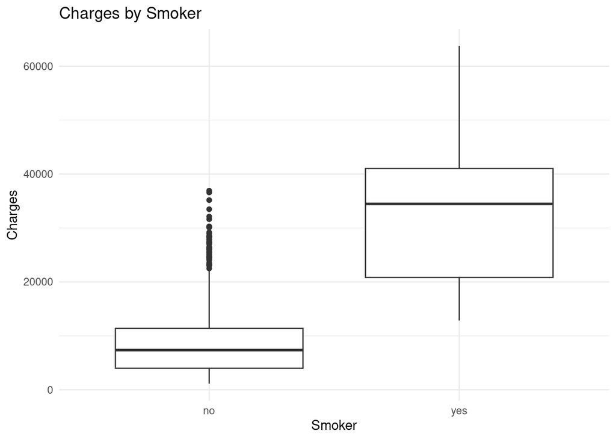

```r
print(p2)
```

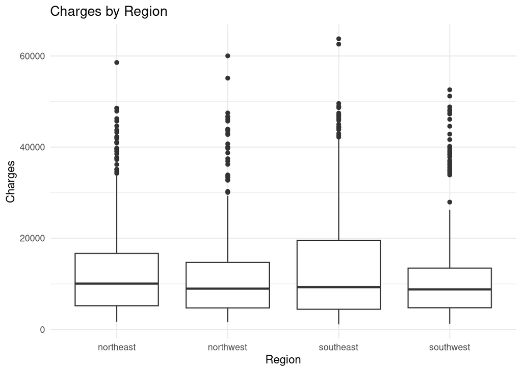

```r
print(p3)
```

## 5. Объединенные графики

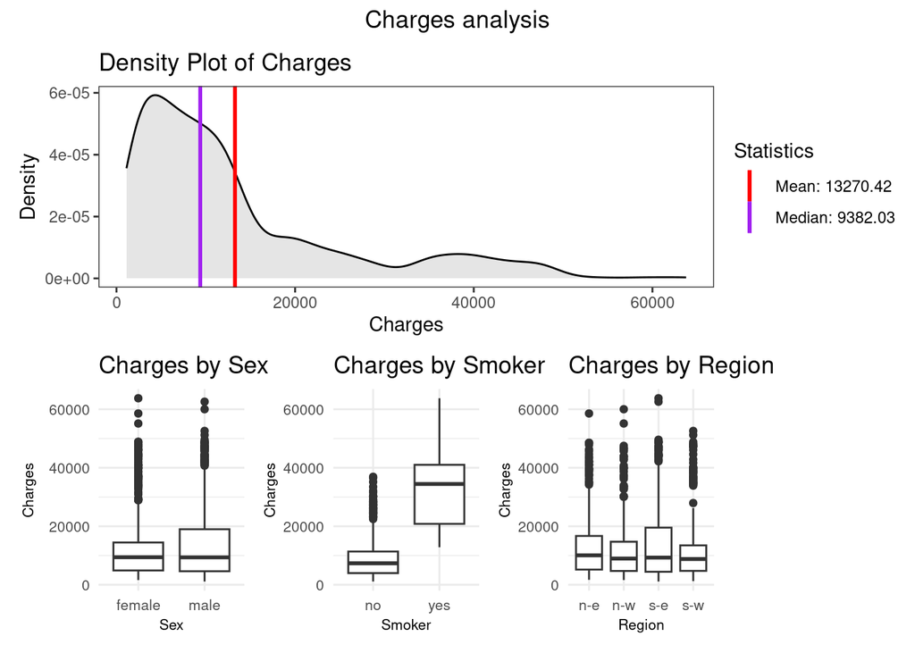

```r
p1 <- p1 + theme(axis.text.x = element_text(size = 8),
                 axis.text.y = element_text(size = 8),
                 axis.title = element_text(size = 8))
p2 <- p2 + theme(axis.text.x = element_text(size = 8),
                 axis.text.y = element_text(size = 8),
                 axis.title = element_text(size = 8))
p3 <- p3 + theme(axis.text.x = element_text(size = 8),
                 axis.text.y = element_text(size = 8),
                 axis.title = element_text(size = 8)) +
           scale_x_discrete(labels=c("northeast" = "n-e", "northwest" = "n-w", "southeast" = "s-e", "southwest" = "s-w"))

final_plot <- gg_charges_density / (p1 | p2 | p3)
final_plot <- final_plot + plot_annotation(title = "Charges analysis", theme = theme(plot.title = element_text(hjust = 0.5),
    plot.title.position = "plot"))
print(final_plot)
```

## 6. Фасет графика плотности переменной charges по колонке region

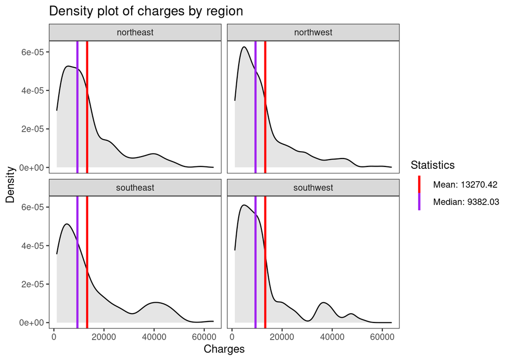

```r
gg_charges_region <- gg_charges_density +
  facet_wrap(~ region) +
  labs(title = "Density plot of charges by region")
print(gg_charges_region)
```

## 7-8. Scatter plot отношения переменных age и charges

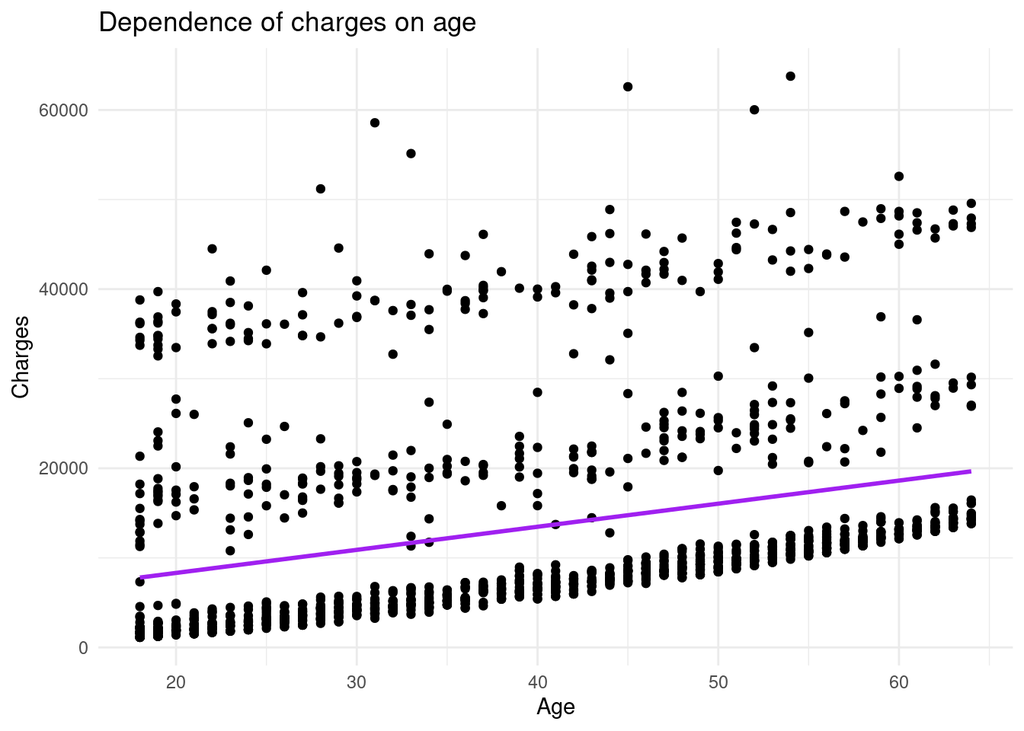

```r
gg_age_charges <- ggplot(data, aes(x=age, y=charges)) +
  geom_point() +
  labs(title = "Dependence of charges on age", x = "Age", y = "Charges") +
  theme(text = element_text(size=14),
        axis.text.x = element_text(size = 14)) +
  geom_smooth(method = "lm", se = FALSE, color = "purple") +
  theme_minimal()

print(gg_age_charges)
```

## 9. Разбивка предыдущего графика по колонке smokers

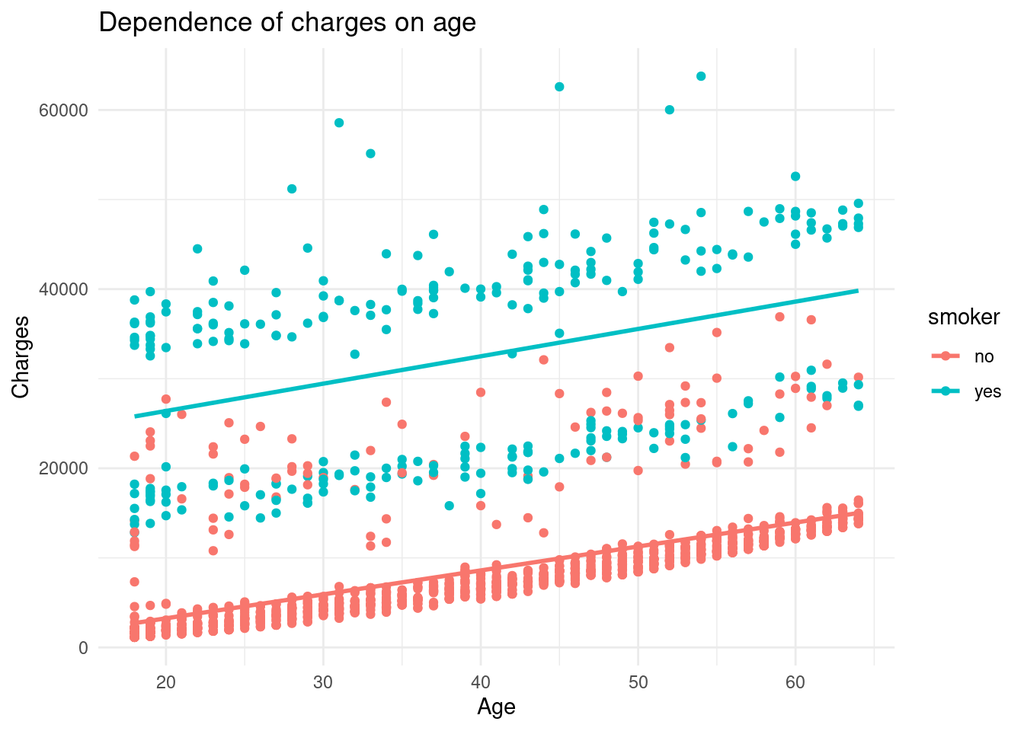

```r
gg_age_charges_smokers <- ggplot(data, aes(x=age, y=charges, color = smoker)) +
  geom_point() +
  labs(title = "Dependence of charges on age", x = "Age", y = "Charges") +
  theme(text = element_text(size=14),
        axis.text.x = element_text(size = 14)) +
  geom_smooth(method = "lm", se = FALSE, aes(group = smoker)) +
  theme_minimal()

print(gg_age_charges_smokers)
```

## 10. Scatter plot отношения переменных bmi (body mass index) и charges

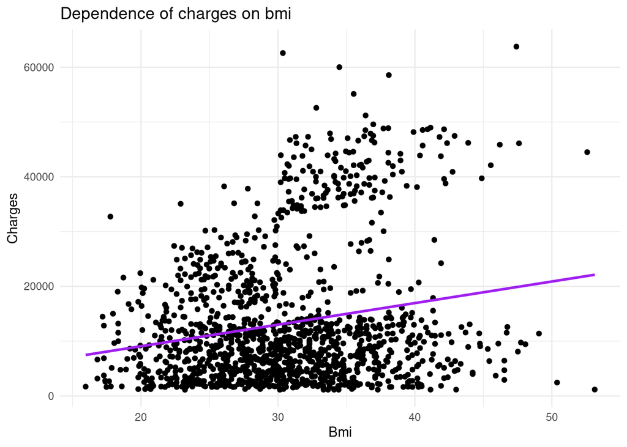

```r
gg_bmi_charges <- ggplot(data, aes(x=bmi, y=charges)) +
  geom_point() +
  labs(title = "Dependence of charges on bmi", x = "Bmi", y = "Charges") +
  theme(text = element_text(size=14),
        axis.text.x = element_text(size = 14)) +
  geom_smooth(method = "lm", se = FALSE, color = "purple") +
  theme_minimal()

print(gg_bmi_charges)
```

## 11. Как пол взаимосвязан с charges?

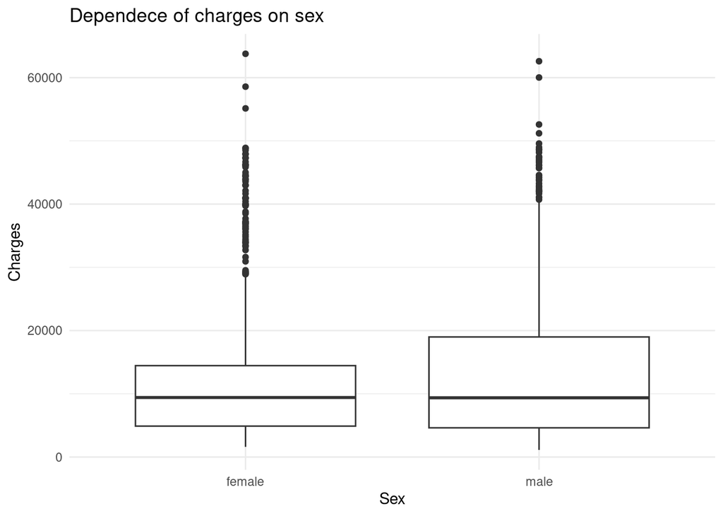

```r
gg_sex_charges <- ggplot(data, aes(x=sex, y = charges)) +
  geom_boxplot() +
  labs(title = "Dependece of charges on sex",
       x = "Sex",
       y = "Charges") +
  theme_minimal()

print(gg_sex_charges)
```

Боксплот хорошо отображает распределение числовой переменной по категориальной. Видим, что медина выплат практически одинакова для обоих полов, однако верхний квартиль для мужчин выше, чем для женщин, а также выбросы для мужчин в основной массе выше, чем у женщин.

## 12. Отношение между age и charges, разделенное по полу.

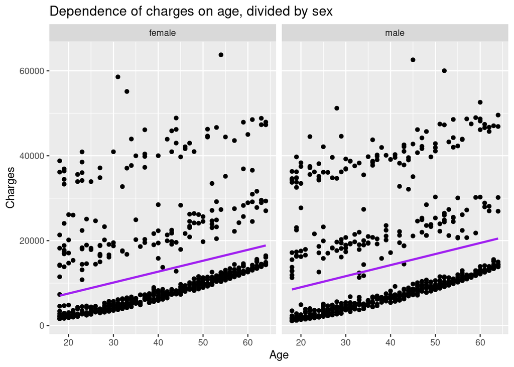

```r
gg_age_charges_sex <-ggplot(data, aes(x = age, y = charges)) +
  geom_point() +
  geom_smooth(method = "lm", se = FALSE, color = "purple") +
  facet_wrap(~ sex) +
  labs(title = "Dependence of charges on age, divided by sex",
       x = "Age",
       y = "Charges")

print(gg_age_charges_sex)
```

Видим, что графики выглядят примерно одинаково, каких-то явных сильных отличий в charges,которые бы зависили от пола и возраста нет. На geom_point хорошо видно все распределение, выбросы и линию тенденции

## 13. Как влияет число детей на charges, с учетом пола?

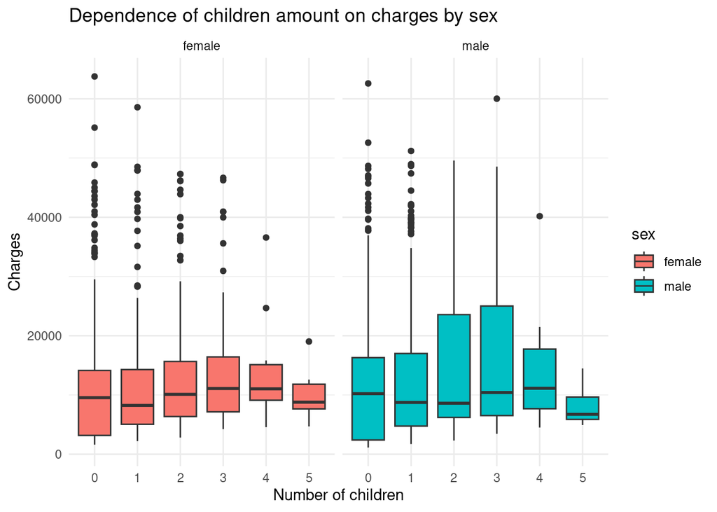

```r
gg_children_sex <- ggplot(data, aes(x=as.factor(children), y = charges, fill = sex)) +
  geom_boxplot() +
  facet_grid(. ~ sex) +
  labs(title = "Dependence of children amount on charges by sex",
       x = "Number of children",
       y = "Charges") +
  theme_minimal()

print(gg_children_sex)
```

Используем boxplot и facet_grid,чтобы разделить мужчин и женщин. Какой-то явной закономерности влияния количества детей на выплаты, в зависимости от пола нет. Однако интересно, что для мужчин с 2-4 детьми верние квартили заметно выше, чем для женщин

## 14. Повторение графика отношения bmi к логарифму charges в зависимости от age (3 возрастные группы: 21-34, 35-49, 50+)

```r
data_age_groups <- data %>%
  mutate(age_group = cut(age,
                         breaks = c(0, 20, 34, 49, Inf),
                         labels = c("under 20", "21-34", "35-49", "50+"),
                         right = TRUE),
         log_charges = log(charges)) %>%
  filter(age_group != "under 20")
head(data_age_groups)
```

```
## # A tibble: 6 × 9
##     age sex      bmi children smoker region    charges age_group log_charges
##   <dbl> <chr>  <dbl>    <dbl> <chr>  <chr>       <dbl> <fct>           <dbl>
## 1    28 male    33          3 no     southeast   4449. 21-34            8.40
## 2    33 male    22.7        0 no     northwest  21984. 21-34           10.0
## 3    32 male    28.9        0 no     northwest   3867. 21-34            8.26
## 4    31 female  25.7        0 no     southeast   3757. 21-34            8.23
## 5    46 female  33.4        1 no     southeast   8241. 35-49            9.02
## 6    37 female  27.7        3 no     northwest   7282. 35-49            8.89
```

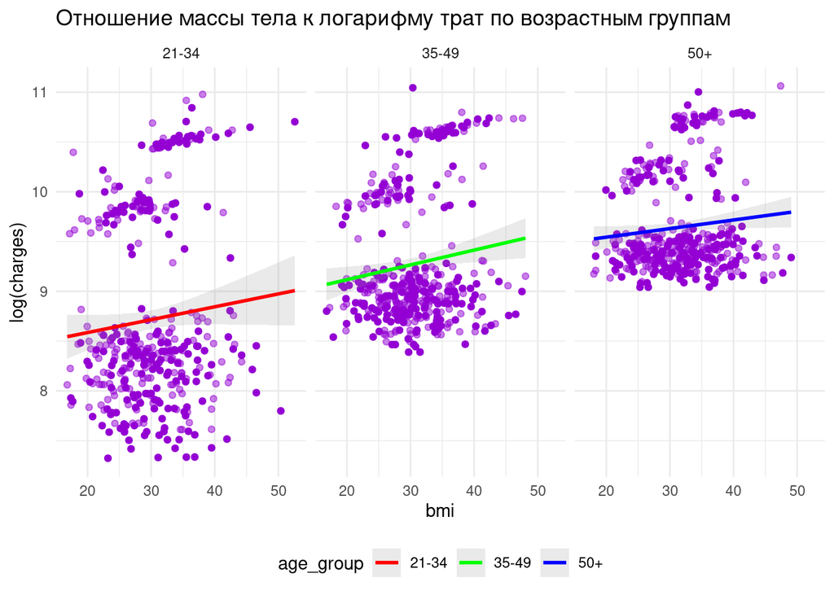

```r
gg_bmi_charges_age <- ggplot(data_age_groups, aes(x = bmi, y = log_charges)) +
  geom_point(aes(alpha = sex), color = "darkviolet") +
  geom_smooth(method = "lm", se = TRUE, aes(color = age_group), alpha = 0.2) +
  scale_color_manual(values = c("21-34" = "red", "35-49" = "green", "50+"= "blue")) +
  scale_alpha_manual(values= c("male" = 1, "female" = 0.5), guide = "none") +
  facet_grid(~ age_group) +
  labs(title = "Отношение массы тела к логарифму трат по возрастным группам",
       x = "bmi",
       y = "log(charges)") +
  theme_minimal() +
  theme(legend.position = "bottom")

print(gg_bmi_charges_age)
```